# Temas Tratados en el Trabajo Práctico 7

- Teoría de utilidad.
- Toma de decisiones basadas en utilidad.
- Valor de la información.
- Ganancia y entropía.
- Algoritmos basados en la teoría de la decisión.
- Sistemas expertos.

## Ejercicios Teóricos

1. ¿Qué representa una función de utilidad?

La **Función de Utilidad** representa matemáticamente las preferencias de los agentes económicos, específicamente representa la utilidad o satisfacción que estos obtienen a partir de ciertas combinaciones de bienes o servicios.

2. Respondan las siguientes preguntas. Cada respuesta corresponde a un axioma de la utilidad, indique cuál se relaciona con cada pregunta y dé una breve explicación de lo que dice el axioma.

2.1 ¿Qué color prefieren?

[figure not shown]

```python
import requests
from PIL import Image
from io import BytesIO
import matplotlib.pyplot as plt

# URLs directas de Google Drive
url1 = "https://drive.google.com/uc?export=view&id=1aofwvS7bUVmKS6MlTcpL2ZgVa9JuGJex"
url2 = "https://drive.google.com/uc?export=view&id=1-htp7twx9y5-GpzMUXl9hk-X3kV-BVz6"

# Función para descargar y redimensionar imagen
def load_and_resize(url, size=(10, 10)):
    response = requests.get(url)
    img = Image.open(BytesIO(response.content))
    img = img.resize(size, Image.Resampling.LANCZOS)  # redimensionar a 150x150
    return img

# Cargar imágenes
img1 = load_and_resize(url1)
img2 = load_and_resize(url2)

# Crear figura con 2 columnas
fig, axes = plt.subplots(1, 2, figsize=(5, 5))

# Mostrar primera imagen
axes[0].imshow(img1)
axes[0].axis('off')
axes[0].set_title("Color 1")

# Mostrar segunda imagen
axes[1].imshow(img2)
axes[1].axis('off')
axes[1].set_title("Color 2")

plt.tight_layout()
plt.show()
```

Es posible preferir el color de la imágen 1, el de la imágen 2 o ser indiferente a cualquiera de los dos. Esta decisión corresponde al **Axioma de Completitud**: Si A y B son dos estados posibles de un conjunto, entonces se puede preferir A (A>B), se puede preferir B (B>A), o se pueden preferir tanto A como B (A?B)

2.2 Entre sacar un 10 o un 7 en un parcial, ¿qué prefieren? ¿Y entre el 7 y desaprobar?

Si la preferencia es obtener la mayor nota posible, entonces entre un 10 o un 7 se prefiere sacar un 10, y entre sacar un 7 o desaprobar se prefiere sacar un 7. Esta decisión corresponde al **Axioma de Transitividad**: si se tienen 3 estados A, B y C, y se cumple que (A>B) y (B>C), entonces (A>C). Siguiendo el razonamiento de este axioma, se puede concluir que se prefiere sacar un 10 antes que desaprobar.

2.3 Imagínense que hacen una apuesta de $100 jugando al cara o cruz, si pudieran trucar la moneda para que ustedes ganaran un porcentaje *p* de las veces, ¿en qué valor configurarían *p*?

En este caso, debido a que se prefiere el estado A (ganar la apuesta) por sobre B (perder la apuesta), entonces se prefiere la lotería en la que la probabilidad de A sea máxima. Este razonamiento corresponde al **Axioma de Monotonicidad**: Si dos loterías tienen los mismos resultados posibles A y B, y se prefiere A por sobre B, entonces se elige la lotería en la que A tenga la mayor probabilidad de suceder.

2.4 En una feria hay dos juegos: uno en el que el premio son $100 y otro en el que el premio es una piedra, ambos con una probabilidad *p* de ganar al juego. ¿A qué juego prefieren jugar?

Si se define un estado A (ganar 100$), un estado B (ganar una piedra) y un estado C (perder), entonces se prefiere el juego en el que se pueda ganar los 100$ ya que aunque exista la probabilidad de perder, se tiene un mayor beneficio al ganar. Este razonamiento corresponde al **Axioma de Independencia**: Si A se prefiere sobre B, y B se prefiere sobre C, entonces se prefiere una lotería entre A y C antes que una entre B y C.

2.5 En un casino hay dos juegos y en ambos el premio son $1000. El primer juego se gana cuando se tira una moneda y sale cara y el segundo juego se gana cuando sale 6 en un dado. ¿A qué juego prefieren jugar?

Si se define ganar como un estado A y perder como un estado B, se prefiere la lotería en la que la probabilidad P de ganar sea la máxima posible. El juego de la moneda tiene una P(A)=1/2, mientras que el juego del dado tiene P(A)=1/6, por lo tanto se prefiere el juego de la moneda. El razonamiento corresponde al **Axioma de Monotonicidad**.

2.6 Supongamos que quiere postularse a una beca. Primero, existe un 60% de probabilidad de que le llamen para una entrevista. Si no le llaman, entonces hay un 20% de probabilidad de que le ofrezcan participar en un curso online ¿Cuál es la probabilidad total de cada evento (recibir la beca, recibir el curso o no recibir nada)?

- Para el primer caso, tenemos una probabilidad de ganar P=$\frac{1}{50}$, el valor esperado del premio es E[premio]= $\sum$ $ \frac{1}{50} \times 10 $ =0.2 dolares

  El valor monetario esperado se calcula como E[valor neto]= E[premio]-costo_boleto: E[valor neto] = 0.2 - 1 = -0.8 dolares
- Para el segundo caso, tenemos una probabilidad de ganar P=$\frac{1}{2000000}$, el valor esperado del premio es E[premio]= $\sum$ $ \frac{1}{2000000} \times 1000000 $ =0.5 dolares.

  El valor monetario monetario se calcula como E[valor neto]= E[premio]-costo_boleto: E[valor neto]= 0.5 - 1= -0.5 dolares

3.2 ¿Cuándo es razonable comprar un boleto?

En ambos juegos el valor monetario es negativo, por lo que no se gana dinero generalmente, un agente puramente racional nunca jugaria.

Si el usuario desea jugar para tener un poco de diversion, o salir de la pobreza optaria por el juego 2,ya que en promedio se pierde menos dinero que el juego 1 y el premio es mayor.

4. Hay que reparar una máquina averiada y el mecánico diagnostica que si la avería es leve la reparación costará $300, pero si es grave costará $1.200. La probabilidad de que la avería sea grave es 2/3. También se ofrece la alternativa de comprar una máquina usada por $600. Qué decisión se tomará si:

4.1 La función de utilidad fuese la mostrada por el agente rojo.

4.2 La función de utilidad fuese la mostrada por el agente verde.

Datos:

Reparar: - A: si la falla es leve -> 300$. Prob(A)=1/3 - B: si la falla es grave -> 1200$. Prob(B)=2/3 Comprar una usada: 600$. Prob=1

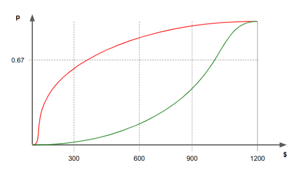

```python
url = "https://drive.google.com/uc?export=view&id=1vNTlLArEhsxTOIvgs-NJ7NcE0B0JPJcw"
response = requests.get(url)
img = Image.open(BytesIO(response.content))

# Mostrar con figura más grande
plt.figure(figsize=(img.width / 80, img.height / 80))  # ajustá el divisor según densidad deseada
plt.imshow(img)
plt.axis('off')
plt.show()
```

## Ejercicios de Implementación

5. En unos laboratorios de un hospital se está investigando sobre una sustancia para la curación de una determinada enfermedad. Dicha sustancia ha sido inyectada en varias cobayas enfermas para verificar sus efectos. Los resultados de las pruebas realizadas se sintetizan en la siguiente tabla:

| **Estado de la enfermedad** | **Concentración de la sustancia** | **Número de dosis** | **Condición física** | **Efecto** |
| --- | --- | --- | --- | --- |
| Incipiente | 75 | 70 | Fuerte | Curación |
| Incipiente | 80 | 90 | Fuerte | Defunción |
| Incipiente | 85 | 85 | Débil | Defunción |
| Incipiente | 62 | 95 | Débil | Defunción |
| Incipiente | 79 | 70 | Débil | Curación |
| Avanzado | 72 | 90 | Fuerte | Curación |
| Avanzado | 83 | 78 | Débil | Curación |
| Avanzado | 64 | 66 | Fuerte | Curación |
| Avanzado | 81 | 75 | Débil | Curación |
| Terminal | 71 | 80 | Fuerte | Defunción |
| Terminal | 65 | 70 | Fuerte | Defunción |
| Terminal | 75 | 80 | Débil | Curación |
| Terminal | 68 | 80 | Débil | Curación |
| Terminal | 70 | 96 | Débil | Curación |

Determine las reglas que rigen las condiciones en las que se ha de administrar una sustancia e implemente un sistema experto en CLIPS que determine si un sujeto resultará curado o no.

Para la resolución de este problema primero discretizamos La concentración de la sustancia y el numero de dosis:

Eo(p=9,n=5) = 0,940

El árbol de decisiones queda:

[figure not shown]

# Bibliografía

[Russell, S. & Norvig, P. (2004) *Inteligencia Artificial: Un Enfoque Moderno*. Pearson Educación S.A. (2a Ed.) Madrid, España](https://www.academia.edu/8241613/Inteligencia_Aritificial_Un_Enfoque_Moderno_2da_Edici%C3%B3n_Stuart_J_Russell_y_Peter_Norvig)

[Poole, D. & Mackworth, A. (2023) *Artificial Intelligence: Foundations of Computational Agents*. Cambridge University Press (3a Ed.) Vancouver, Canada](https://artint.info/3e/html/ArtInt3e.html)